# Tweet Airline NLP Sentiment Analysis

Dylan Chou

# Dependencies

### We make use of abstractions from APIs and packages along with pretrained models to focus on the sentiment prediction task.

```python
#testing with transformers:
#!python -c "from transformers import pipeline; print(pipeline('sentiment-analysis')('website'))"
```

```python
import warnings
warnings.simplefilter("ignore")
```

```python
### data ingestion and visualization
import seaborn as sns
import matplotlib.pyplot as plt
import pandas as pd
from tqdm.notebook import tqdm
from sklearn.utils import shuffle

### natural language
import nltk
from nltk.corpus import stopwords
#nltk.download('vader_lexicon')
# nltk.download('wordnet')
# nltk.download('punkt')
# nltk.download('brown')
import transformers

### vectorization and similarity
from sklearn.feature_extraction.text import TfidfVectorizer
from sklearn.metrics.pairwise import cosine_similarity
from sklearn.feature_extraction.text import CountVectorizer

### text mining
import re
import emoji

### text visualization
from wordcloud import WordCloud, STOPWORDS
from nltk.stem.porter import PorterStemmer

### math
import numpy as np

### oversampling

from imblearn.pipeline import make_pipeline
from imblearn.over_sampling import SMOTE

### train/test split

from sklearn.model_selection import train_test_split
from sklearn.model_selection import StratifiedKFold

### modeling

from sklearn.ensemble import RandomForestClassifier
from sklearn.naive_bayes import ComplementNB
from xgboost import XGBClassifier

from tensorflow import keras
from tensorflow.keras import layers
from keras import backend as K

### metrics for classification

from sklearn.metrics import precision_score, recall_score,\
accuracy_score, f1_score, classification_report, confusion_matrix
from sklearn.metrics import plot_confusion_matrix
```

# Data Ingestion & EDA

### Here we read in the data:

```python
airlineSentiment = pd.read_csv("./Tweets.csv")
```

### Let's get an idea of the dataset:

```python
# getting an idea of the airline sentiments
airlineSentiment.head(4)
```

|  | tweet_id | airline_sentiment | airline_sentiment_confidence | negativereason | negativereason_confidence | airline | airline_sentiment_gold | name | negativereason_gold | retweet_count | text | tweet_coord | tweet_created | tweet_location | user_timezone |
| --- | --- | --- | --- | --- | --- | --- | --- | --- | --- | --- | --- | --- | --- | --- | --- |
| 0 | 570306133677760513 | neutral | 1.0000 | NaN | NaN | Virgin America | NaN | cairdin | NaN | 0 | @VirginAmerica What @dhepburn said. | NaN | 2015-02-24 11:35:52 -0800 | NaN | Eastern Time (US & Canada) |
| 1 | 570301130888122368 | positive | 0.3486 | NaN | 0.0000 | Virgin America | NaN | jnardino | NaN | 0 | @VirginAmerica plus you've added commercials t... | NaN | 2015-02-24 11:15:59 -0800 | NaN | Pacific Time (US & Canada) |
| 2 | 570301083672813571 | neutral | 0.6837 | NaN | NaN | Virgin America | NaN | yvonnalynn | NaN | 0 | @VirginAmerica I didn't today... Must mean I n... | NaN | 2015-02-24 11:15:48 -0800 | Lets Play | Central Time (US & Canada) |
| 3 | 570301031407624196 | negative | 1.0000 | Bad Flight | 0.7033 | Virgin America | NaN | jnardino | NaN | 0 | @VirginAmerica it's really aggressive to blast... | NaN | 2015-02-24 11:15:36 -0800 | NaN | Pacific Time (US & Canada) |

```python
airlineSentiment['airline'].unique()
```

```
array(['Virgin America', 'United', 'Southwest', 'Delta', 'US Airways',
       'American'], dtype=object)
```

### Below are visualizations of the target variable followed by the negative reason for a negative airline sentiment.

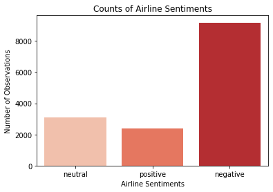

```python
sentimentPlot = sns.countplot(x="airline_sentiment",data=airlineSentiment,palette="Reds")
sentimentTitle = sentimentPlot.set_title("Counts of Airline Sentiments")
sentimentYLab = sentimentPlot.set_ylabel("Number of Observations")
sentimentXLab = sentimentPlot.set_xlabel("Airline Sentiments")
```

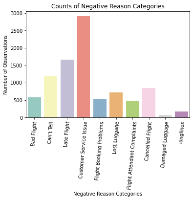

```python
# here we exclude the NaN negative reason from the count plot
negativereasonPlot = sns.countplot(x="negativereason",data=airlineSentiment,palette="Set3")
title = negativereasonPlot.set_title("Counts of Negative Reason Categories")
yLabels = negativereasonPlot.set_ylabel("Number of Observations")
xLabels = negativereasonPlot.set_xlabel("Negative Reason Categories")
negativeReasonXticklabels = negativereasonPlot.set_xticklabels(negativereasonPlot.get_xticklabels(), rotation=85)
```

### We can group the sentiments by airline. Some airlines may be viewed more negatively.

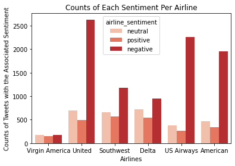

```python
sentimentByAirline = sns.countplot(x="airline",
                                   hue="airline_sentiment",
                                   data=airlineSentiment,
                                   palette="Reds")
sentimentByAirlinetitle = sentimentByAirline.set_title("Counts of Each Sentiment Per Airline")
sentimentByAirlineXLab = sentimentByAirline.set_ylabel("Counts of Tweets with the Associated Sentiment")
sentimentByAirlineYLab = sentimentByAirline.set_xlabel("Airlines")
```

### Oh would you look at that! United has the most negative tweets. Virgin America has a relatively equal amount of tweets that are negative, neutral and positive, but there are less tweets overall: it may not be representative of what most people think who have taken Virgin America. The others have more negative tweets than neutral and positive ones.

### And below we can see that a total of 7701 unique users tweeted about the above airlines

```python
numUniqueUserTweets = len(airlineSentiment['name'].unique())
print("Number of Unique Users Who Tweeted:", numUniqueUserTweets)
```

```
Number of Unique Users Who Tweeted: 7701
```

### The text itself with its associated label is what's relevant to sentiment analysis of the airline tweets.

### The analysis of sentiment in the tweets can carry over to prediction of generalized sentences.

#### An issue is that some of the sentiment labels are not very confident such as the 2nd row (34.86%)

```python
modifiedAirlineDf = airlineSentiment[["text","airline_sentiment","airline_sentiment_confidence"]]
modifiedAirlineDf.head()
```

|  | text | airline_sentiment | airline_sentiment_confidence |
| --- | --- | --- | --- |
| 0 | @VirginAmerica What @dhepburn said. | neutral | 1.0000 |
| 1 | @VirginAmerica plus you've added commercials t... | positive | 0.3486 |
| 2 | @VirginAmerica I didn't today... Must mean I n... | neutral | 0.6837 |
| 3 | @VirginAmerica it's really aggressive to blast... | negative | 1.0000 |
| 4 | @VirginAmerica and it's a really big bad thing... | negative | 1.0000 |

#### We can eliminate tweets that may not be correctly labeled: integrity of the data labeling.

```python
airlineDf = modifiedAirlineDf[modifiedAirlineDf["airline_sentiment_confidence"] > 0.62].reset_index(drop=True)
airlineDf = airlineDf[["text","airline_sentiment"]]
airlineDf.head()
```

|  | text | airline_sentiment |
| --- | --- | --- |
| 0 | @VirginAmerica What @dhepburn said. | neutral |
| 1 | @VirginAmerica I didn't today... Must mean I n... | neutral |
| 2 | @VirginAmerica it's really aggressive to blast... | negative |
| 3 | @VirginAmerica and it's a really big bad thing... | negative |
| 4 | @VirginAmerica seriously would pay $30 a fligh... | negative |

### We can also consider making a numerical column for the sentiments

```python
airlineDf['numSentiment'] = airlineDf["airline_sentiment"].apply(
                                lambda sentiment: 1 if sentiment == "negative"
                                else (2 if sentiment == "neutral" else 3))
```

```python
airlineDf.head()
```

|  | text | airline_sentiment | numSentiment |
| --- | --- | --- | --- |
| 0 | @VirginAmerica What @dhepburn said. | neutral | 2 |
| 1 | @VirginAmerica I didn't today... Must mean I n... | neutral | 2 |
| 2 | @VirginAmerica it's really aggressive to blast... | negative | 1 |
| 3 | @VirginAmerica and it's a really big bad thing... | negative | 1 |
| 4 | @VirginAmerica seriously would pay $30 a fligh... | negative | 1 |

## Data Engineering

### It's important to perform text mining on the tweets to ensure that emojis and numeric values are not included as input into the prediction model. If input data is not of good quality, then garbage into a model = garbage out

### When text mining, we could perform lemmatization that "groups together" inflections of the same word - this can come from stemming words be taking "admirals" to be "admir". We could use lemmatization when identifying matches between words, but it's used on a case-by-case basis. Unless it improves model out-of-sample performance, we don't need to use PorterStemmer, for instance.

### One thing to note about the text column is that there are cases with hashtags like this:

```python
hashtag = airlineDf[airlineDf['text'].str.contains('neverflyvirgin')]["text"].iloc[0]
print("Chain of words without spaces:", hashtag[111:])
```

```
Chain of words without spaces: #neverflyvirginforbusiness
```

### To solve the issue of chains of words in hashtags, we can use dynamic programming. We can split a chain of words in many ways such as "Imanage" becoming "I man age" or "I manage". Not all splits will result in a valid set of words. And not all valid splits are equally likely. We want the most likely split in the chain of words.

```python
from nltk.corpus import words
# add 1 to avoid log of 0 error
wordList = words.words()
numWords = len(wordList)
costs = {word:(np.log((rank+1)*(np.log(numWords)))) for rank, word in enumerate(wordList)}
longestWordLength = max(list(map(lambda word: len(word), wordList)))
```

```python
# A naive approach would not rely on memoization and use recursion to obtain prefixes along with the costs,
# and reducing to find the sequence of words resulting in the minimum cost, greatest likelihood of
# occurring.
# We could store a memoization table:
def splitWordChain(chain: str) -> list:
    dim = len(chain)
    memo = [(0,0)]*(dim+1)
    splitChain = []
    for end in range(1,dim+1):
        minCostAndWord = (float('inf'),0)
        for start in range(max(0,end-longestWordLength), end):
            costAndWord = (memo[start][0]+costs.get(chain[start:end],float('inf')), end-start)
            if costAndWord < minCostAndWord:
                minCostAndWord = costAndWord
        memo[end] = minCostAndWord
    # one could merge the two loops together and instead have 1 loop, but here
    # both are in same big-O.
    pos = dim
    # in reverse to obtain min-cost backwards - first in memo costs is a placeholder - 0's.
    while pos > 0:
        cost, length = memo[pos]
        if length == 0:
            return '' # no valid splitting
        splitChain += [chain[pos-length:pos]]
        pos -= length
    return ' '.join(reversed(splitChain))
```

### And splitWordChain can split up the hashtag chain

```python
print(hashtag)
print(splitWordChain("neverflyvirginforbusiness"))
```

```
@VirginAmerica why can't you supp the biz traveler like @SouthwestAir  and have customer service like @JetBlue #neverflyvirginforbusiness
never fly virgin for business
```

```python
airlineDf[airlineDf['text'].str.contains("http")]
```

|  | text | airline_sentiment | numSentiment |
| --- | --- | --- | --- |
| 6 | @VirginAmerica Really missed a prime opportuni... | neutral | 2 |
| 12 | @VirginAmerica @virginmedia I'm flying your #f... | positive | 3 |
| 20 | @VirginAmerica I love this graphic. http://t.c... | positive | 3 |
| 32 | @VirginAmerica this is great news! America co... | positive | 3 |
| 33 | Nice RT @VirginAmerica: Vibe with the moodligh... | neutral | 2 |
| ... | ... | ... | ... |
| 14273 | @AmericanAir I hope you like the photo :) http... | positive | 3 |
| 14307 | @AmericanAir seems like queue times are very h... | negative | 1 |
| 14325 | http://t.co/EIw2sYb8Fu roberts&amp;s=1 @Americ... | neutral | 2 |
| 14350 | @AmericanAir Flight 236 was great. Fantastic c... | positive | 3 |
| 14357 | “@AmericanAir: @TilleyMonsta George, that does... | neutral | 2 |

1148 rows × 3 columns

### With tweet mining, keeping stopwords could be important. "The website is down" vs exclusion of "down", a stopword, could make a difference between negative and positive sentiment prediction, respectively.

```python
from nltk.stem import PorterStemmer
ps = PorterStemmer()
def mineTweet(text):
    # set that doesn't necessarily contribute to the overall sentiment
    airlines = {"virginamerica","usairways",
                "americanair","united",
                "southwestair","jetblue"}
    singleLetters = {'a','u','y','r'}
    # all lowercase
    OutText = text.lower()
    OutText = re.sub(r'<[^<]+?>','', OutText)

    # removing unimportant links - http - can affect length of sentence -
    # "document size/length" and remove any non-space values after http
#     OutText = re.sub(r'http\S+',' ', OutText)
    OutText = ' '.join([splitWordChain(item[1:]) if (item.startswith("#") and item[1:].isalpha()) else item
                        for item in OutText.split()])
    OutText = ' '.join([item for item in OutText.split() if "http" not in item])
    # remove emojis - after demojizing, the text will have
    # colons : around the text form of the emoji.
    OutText = re.sub(r':', ' ', emoji.demojize(OutText))
    # we remove symbols and numbers from the text
    OutText = re.sub(r'[^a-z]', ' ', OutText)

    # we split the sentence into individual words
    words = OutText.split()
    # we remove words that are from airlines
    words = [ps.stem(word) for word in words if (word not in airlines) and (len(word) > 1 or (len(word)==1) and word in singleLetters)]
    return words
```

```python
airlineDf['minedText'] = airlineDf['text'].apply(lambda text: mineTweet(text))
# We also use the sentence size as "document size" to be used
# in term-frequency inverse document frequency
# calculations.
airlineDf['textLength'] = airlineDf['minedText'].apply(lambda minedText: len(minedText))
airlineDf['minedText'] = airlineDf['minedText'].apply(lambda text: ' '.join(text))
```

### We could also look at word clouds to see words associated with each sentiment

```python
def displaySentiment(sentimentNumber):
    cloud = WordCloud(width=1000, height=500,
              random_state=1, colormap='Pastel2',
              stopwords=STOPWORDS).generate\
              (' '.join(airlineDf[airlineDf['numSentiment']==sentimentNumber]["minedText"].values))
    imagePositive = plt.imshow(cloud)
```

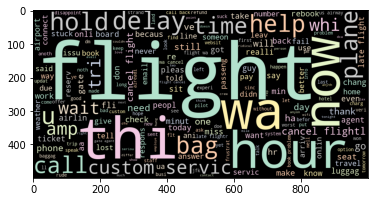

```python
displaySentiment(1)
```

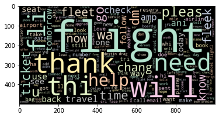

```python
displaySentiment(2)
```

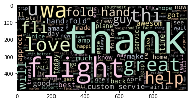

```python
displaySentiment(3)
```

### Word Cloud of Sentiments show that negative tweets complain about flights being on "hold", delays and cancellations in flights. Positive tweets are associated with thank, love, and great, likely commenting on the customer service.

### Stratified K Fold Cross Validation is done for the methods to enable equal sampling of respective classes per cross-validation iteration. This should handle imbalances in data.

```python
kfold = StratifiedKFold(n_splits=10, shuffle=True, random_state=101)
```

## Method 1: NLTK Vader Classifier

```python
# we have the Valence Aware Dictionary for Sentiment Reasoning
from nltk.sentiment.vader import SentimentIntensityAnalyzer
vaderModel1 = SentimentIntensityAnalyzer()
```

```python
def labelVader(text):
    compoundScore = vaderModel1.polarity_scores(text)['compound']
    if compoundScore == 0:
        return "neutral"
    elif compoundScore > 0:
        return "positive"
    else:
        return "negative"
```

```python
def roundLst(L,n):
    return [round(num,n) for num in L]

def displayVaderMetrics(X,Y):
    average_method = 'macro'
    accuracies, f1s, precisions, recalls = [],[],[],[]
    for _, test in tqdm(kfold.split(X,Y)):
        prediction = X.iloc[test].apply(lambda text: labelVader(text))
        accuracies.append(accuracy_score(Y.iloc[test],
                                        prediction))
        f1s.append(f1_score(Y.iloc[test],prediction,average="macro"))
        precisions.append(precision_score(Y.iloc[test],
                                          prediction,average='macro'))
        recalls.append(recall_score(Y.iloc[test],
                                    prediction,average='macro'))
    print("Accuracies:",roundLst(accuracies,3))
    print("Mean Accuracy:",np.mean(accuracies))
    print("F1 Scores:",roundLst(f1s,3))
    print("Mean F1:",np.mean(f1s))
    print("Precisions:",roundLst(precisions,3))
    print("Mean Precision:",np.mean(precisions))
    print("Recalls:",roundLst(recalls,3))
    print("Mean Recall:",np.mean(recalls))

displayVaderMetrics(airlineDf["minedText"],
                    airlineDf['airline_sentiment'])
```

```
Accuracies: [0.495, 0.54, 0.51, 0.523, 0.522, 0.529, 0.543, 0.499, 0.528, 0.522]
Mean Accuracy: 0.5211651672956853
F1 Scores: [0.468, 0.511, 0.479, 0.5, 0.497, 0.503, 0.519, 0.471, 0.498, 0.496]
Mean F1: 0.4943389219808566
Precisions: [0.503, 0.54, 0.513, 0.53, 0.53, 0.532, 0.546, 0.507, 0.53, 0.532]
Mean Precision: 0.5260638333679146
Recalls: [0.557, 0.607, 0.562, 0.596, 0.582, 0.597, 0.614, 0.561, 0.579, 0.588]
Mean Recall: 0.5843387226152368
```

### The f1 score will be used as the primary metric for comparison due to imbalance between output sentiment classes. We have a fairly low precision score here, which indicates that there were more false positives. This could be from labeling a text as negative (majority) when it was not.

## Method 2: Transformer - HuggingFace

```python
from transformers import pipeline
```

```python
# pretrained pipeline usage
transformerModel2 = pipeline('sentiment-analysis')
```

```python
def labelHuggingFace(text):
    dictResult = transformerModel2(text)[0]
    # neutral confidence with regards to predicted label
    if dictResult['score'] < 0.6:
        return 'neutral'
    else:
        return dictResult['label'].lower()
```

```python
# "folded-validation error"
def displayHuggingFaceMetrics(X,Y):
    average_method = 'macro'
    accuracies, f1s, precisions, recalls = [],[],[],[]
    for _, test in tqdm(kfold.split(X,Y)):
        prediction = X.iloc[test].apply(lambda text: labelHuggingFace(text))
        accuracies.append(accuracy_score(Y.iloc[test],
                                        prediction))
        f1s.append(f1_score(Y.iloc[test],prediction,average="macro"))
        precisions.append(precision_score(Y.iloc[test],
                                          prediction,average='macro'))
        recalls.append(recall_score(Y.iloc[test],
                                    prediction,average='macro'))
    print("Accuracies:",roundLst(accuracies,3))
    print("Mean Accuracy:",np.mean(accuracies))
    print("F1 Scores:",roundLst(f1s,3))
    print("Mean F1:",np.mean(f1s))
    print("Precisions:",roundLst(precisions,3))
    print("Mean Precision:",np.mean(precisions))
    print("Recalls:",roundLst(recalls,3))
    print("Mean Recall:",np.mean(recalls))

displayHuggingFaceMetrics(airlineDf["minedText"],
                          airlineDf['airline_sentiment'])
```

```
Accuracies: [0.685, 0.704, 0.695, 0.68, 0.696, 0.699, 0.69, 0.696, 0.687, 0.708]
Mean Accuracy: 0.6938883428994558
F1 Scores: [0.469, 0.496, 0.481, 0.471, 0.488, 0.491, 0.48, 0.499, 0.475, 0.5]
Mean F1: 0.4849195100581144
Precisions: [0.493, 0.52, 0.502, 0.459, 0.532, 0.557, 0.52, 0.583, 0.477, 0.547]
Mean Precision: 0.5191219310808586
Recalls: [0.542, 0.575, 0.544, 0.543, 0.546, 0.56, 0.543, 0.555, 0.536, 0.565]
Mean Recall: 0.5507595573517188
```

### The F1 score of the huggingface transformer model is lower than that of vader. Here we see how the imbalance in data lowers f1 much more in huggingface than vader. Huggingface also has lower precision than vader, which indicates more false positives. Recall also appears to be lower than vader's, which indicates more false negatives (e.g. labeled not as negative sentiment, but is negative).

# Method 3: Random Forests and Naive Bayes

### With regards to choosing the right machine learning model to predict sentiment in text, we have looked at the previous two models that were pretrained and have mediocre accuracy. In general, neural networks and deep learning are not extremely intuitive and they may be stuck at local optima or overfit. For more intuitive results in shorter time, we can use random forests - an ensemble method using multiple decision trees and returning the "mean" prediction at the end - and naive bayes.

### Oversampled classes may lead classifiers to be biased in predictions of one class over another. Notably, there are many more negative tweets about airlines than other sentiments.

### One way to handle majority classes is to perform the synthetic minority oversampling technique (SMOTE). An example is shown below from [a paper](https://arxiv.org/pdf/2009.07352.pdf) I wrote.

[figure not shown]

```python
# with lemmatization, we cap off features in vectorized words to 930 as that's the result
# for the test set.
cv = CountVectorizer(max_features=930)
newMined = cv.fit_transform(list(airlineDf['minedText'])).toarray()
newX = pd.concat([pd.DataFrame(data=newMined),airlineDf['textLength']],axis=1)
```

```python
forestModel3 = RandomForestClassifier(n_estimators=100,criterion='gini',random_state=101)
```

```python
cnbModel4 = ComplementNB()
```

```python
def kFoldModel(model):
    average_method = 'macro'
    accuracies, f1s, precisions, recalls = [],[],[],[]
    fits = []
    for train, test in tqdm(kfold.split(newX,airlineDf['numSentiment'])):
        fitted = model.fit(newX.iloc[train], airlineDf['numSentiment'].iloc[train])
        fits.append(model)
        prediction = fitted.predict(newX.iloc[test])
        accuracies.append(accuracy_score(airlineDf['numSentiment'].iloc[test],
                                        prediction))
        f1s.append(f1_score(airlineDf['numSentiment'].iloc[test],
                            prediction,average="macro"))
        precisions.append(precision_score(airlineDf['numSentiment'].iloc[test],
                                          prediction,average='macro'))
        recalls.append(recall_score(airlineDf['numSentiment'].iloc[test],
                                    prediction,average='macro'))
    print("Accuracies:",roundLst(accuracies,3))
    print("Mean Accuracy:",np.mean(accuracies))
    print("F1 Scores:",roundLst(f1s,3))
    print("Mean F1:",np.mean(f1s))
    print("Precisions:",roundLst(precisions,3))
    print("Mean Precision:",np.mean(precisions))
    print("Recalls:",roundLst(recalls,3))
    print("Mean Recall:",np.mean(recalls))
    return fits
```

```python
fitForest3 = kFoldModel(forestModel3)
```

```
Accuracies: [0.781, 0.777, 0.785, 0.788, 0.774, 0.787, 0.783, 0.772, 0.774, 0.778]
Mean Accuracy: 0.7798655412176793
F1 Scores: [0.695, 0.678, 0.695, 0.697, 0.677, 0.696, 0.689, 0.67, 0.676, 0.679]
Mean F1: 0.6852448502949608
Precisions: [0.769, 0.736, 0.768, 0.763, 0.753, 0.762, 0.779, 0.762, 0.767, 0.749]
Mean Precision: 0.760842958561692
Recalls: [0.656, 0.652, 0.657, 0.663, 0.64, 0.665, 0.65, 0.63, 0.634, 0.643]
Mean Recall: 0.6490514621621455
```

```python
fitCNB4 = kFoldModel(cnbModel4)
```

```
Accuracies: [0.775, 0.756, 0.771, 0.765, 0.792, 0.781, 0.781, 0.782, 0.774, 0.775]
Mean Accuracy: 0.775204261431371
F1 Scores: [0.717, 0.693, 0.71, 0.705, 0.728, 0.723, 0.718, 0.714, 0.714, 0.71]
Mean F1: 0.7131495929368097
Precisions: [0.706, 0.68, 0.698, 0.691, 0.722, 0.711, 0.709, 0.709, 0.706, 0.702]
Mean Precision: 0.7034273373775248
Recalls: [0.734, 0.716, 0.73, 0.731, 0.74, 0.746, 0.73, 0.724, 0.728, 0.725]
Mean Recall: 0.7302053716021311
```

```python
xgbBoost = XGBClassifier(max_depth=5,subsample=0.6,
                         reg_lambda=4, gamma=3.5)
```

```python
fitXGB = kFoldModel(xgbBoost)
```

[output not shown]

### Introducing SMOTE

```python
smoteCNBPipelineModel5 = make_pipeline(SMOTE(random_state=101), cnbModel4)
```

```python
fitscnbsmote = kFoldModel(smoteCNBPipelineModel5)
```

```
Accuracies: [0.779, 0.775, 0.763, 0.771, 0.776, 0.792, 0.777, 0.781, 0.767, 0.77]
Mean Accuracy: 0.7752027591527536
F1 Scores: [0.674, 0.658, 0.647, 0.659, 0.663, 0.686, 0.669, 0.669, 0.648, 0.655]
Mean F1: 0.6627068978037032
Precisions: [0.763, 0.748, 0.738, 0.75, 0.762, 0.786, 0.745, 0.774, 0.76, 0.749]
Mean Precision: 0.7575540387817324
Recalls: [0.644, 0.643, 0.62, 0.632, 0.632, 0.662, 0.645, 0.637, 0.619, 0.626]
Mean Recall: 0.6360717607902818
```

```python
smoteForestPipelineModel6 = make_pipeline(SMOTE(random_state=101), forestModel3)
```

```python
fitsforestpipeline = kFoldModel(smoteForestPipelineModel6)
```

```
Accuracies: [0.753, 0.752, 0.764, 0.764, 0.76, 0.767, 0.767, 0.769, 0.749, 0.755]
Mean Accuracy: 0.7600952153879853
F1 Scores: [0.673, 0.672, 0.69, 0.695, 0.685, 0.691, 0.694, 0.689, 0.671, 0.678]
Mean F1: 0.6838249899496567
Precisions: [0.677, 0.669, 0.695, 0.692, 0.683, 0.693, 0.699, 0.697, 0.68, 0.682]
Mean Precision: 0.6867876441788812
Recalls: [0.67, 0.677, 0.685, 0.699, 0.688, 0.695, 0.689, 0.684, 0.663, 0.674]
Mean Recall: 0.6825809001966101
```

```python
smoteXGBoostPipelineModel7 = make_pipeline(SMOTE(random_state=101),xgbBoost)
fitsXGBoostPipeline = kFoldModel(smoteXGBoostPipelineModel7)
```

[output not shown]

```python
from keras import models
from keras import layers
from keras import regularizers


maxLength = max(airlineDf['textLength'])
```

```python
from sklearn.preprocessing import LabelEncoder
from keras.preprocessing.text import Tokenizer
from keras.preprocessing.sequence import pad_sequences
from keras.utils.np_utils import to_categorical
from sklearn.preprocessing import LabelEncoder

XTrain = airlineDf['minedText']

tokenizer = Tokenizer(num_words=15000,
               filters='!"#$%&()*+,-./:;<=>?@[\\]^_`{|}~\t\n',
               lower=True,
               split=" ")

tokenizer.fit_on_texts(XTrain)

encoder = LabelEncoder()
```

### Here, we add a keras model into the mix. The dropouts are intended to reduce overfitting and softmax is for predicting the output sentiment class. 10-Fold is done here as well.

```python
kerasExtraModel = models.Sequential()
kerasExtraModel.add(layers.Embedding(15000, 50, input_length=maxLength))
kerasExtraModel.add(keras.layers.Flatten())
kerasExtraModel.add(keras.layers.Dense(10, activation='tanh'))
kerasExtraModel.add(keras.layers.Dropout(0.5))
kerasExtraModel.add(keras.layers.Dense(10, activation='relu'))
kerasExtraModel.add(keras.layers.Dropout(0.5))
kerasExtraModel.add(layers.Dense(3, activation='softmax'))
kerasExtraModel.summary()
kerasExtraModel.compile(optimizer='adam',
                        loss='categorical_crossentropy',
                        metrics=['accuracy'])
stopEarly = keras.callbacks.EarlyStopping(monitor='val_loss', patience=5)
def kFoldKerasModel(X,Y):
    for train, test in tqdm(kfold.split(X,Y)):
        XTrainSeq = tokenizer.texts_to_sequences(X.iloc[train])
        XTrainSeq = pad_sequences(XTrainSeq, maxlen=maxLength)
        XTestSeq = tokenizer.texts_to_sequences(X.iloc[test])
        XTestSeq = pad_sequences(XTestSeq, maxlen=maxLength)

        YTrain = to_categorical(encoder.fit_transform(Y.iloc[train]))

        YTest = to_categorical(encoder.fit_transform(Y.iloc[test]))

        kerasExtraModel.fit(XTrainSeq,YTrain,epochs=10,batch_size=128,
                            validation_data=(XTestSeq, YTest),
                            verbose=1,callbacks=[stopEarly])
        predictions = kerasExtraModel.predict_classes(XTestSeq)
        yTestLabels = list(map(lambda arr: np.where(arr==1)[0][0], YTest))
        print("Accuracy:", accuracy_score(predictions, yTestLabels))
        print("F1 score:", f1_score(predictions, yTestLabels, average='macro'))
        print("Precision:", precision_score(predictions, yTestLabels,average='macro'))
        print("Recall:", recall_score(predictions, yTestLabels, average='macro'))
        print("---")


kFoldKerasModel(airlineDf["minedText"],airlineDf["airline_sentiment"])
```

```
Model: "sequential_16"
_________________________________________________________________
Layer (type)                 Output Shape              Param #
=================================================================
embedding_16 (Embedding)     (None, 89, 50)            750000
_________________________________________________________________
flatten_16 (Flatten)         (None, 4450)              0
_________________________________________________________________
dense_48 (Dense)             (None, 10)                44510
_________________________________________________________________
dropout_32 (Dropout)         (None, 10)                0
_________________________________________________________________
dense_49 (Dense)             (None, 10)                110
_________________________________________________________________
dropout_33 (Dropout)         (None, 10)                0
_________________________________________________________________
dense_50 (Dense)             (None, 3)                 33
=================================================================
Total params: 794,653
Trainable params: 794,653
Non-trainable params: 0
_________________________________________________________________
```

```
Accuracy: 0.7703549060542797
F1 score: 0.6909251993289104
Precision: 0.68808542063136
Recall: 0.6939096911176948
---
Accuracy: 0.9359777313848295
F1 score: 0.9051460741278669
Precision: 0.9118539891377733
Recall: 0.9012583533824493
---
Accuracy: 0.9700765483646486
F1 score: 0.9583374979177078
Precision: 0.9525513865597685
Recall: 0.9656051919738383
---
Accuracy: 0.9846903270702854
F1 score: 0.9781088887925357
Precision: 0.9777264986608207
Recall: 0.9787904594151393
---
Accuracy: 0.9832869080779945
F1 score: 0.9735374888612317
Precision: 0.9753294568377578
Recall: 0.9718775907609848
---
Accuracy: 0.9825905292479109
F1 score: 0.9734828159237175
Precision: 0.9758625612387535
Recall: 0.9717533977555712
---
Accuracy: 0.9944289693593314
F1 score: 0.992415758587648
Precision: 0.993308257737788
Recall: 0.9915592106186165
---
Accuracy: 0.9909470752089137
F1 score: 0.9874302156910852
Precision: 0.9870401359763186
Recall: 0.9878633554343136
---
Accuracy: 0.9888579387186629
F1 score: 0.9835396389409433
Precision: 0.9815844230105534
Recall: 0.9855282995454301
---
Accuracy: 0.9909470752089137
F1 score: 0.9859757511684957
Precision: 0.9849401277085398
Recall: 0.987078778241569
---
```

### In the last fold, the metrics are all relatively high, at around 98% accuracy, F1 score, precision and recall.